The data for this post is located at https://github.com/muschellij2/FSLR_data, and was graciously allowed by our colleagues who collected it at the NIH.

# Goal of the post

The overall goal of this post is to present a complete preprocessing pipeline for structural magnetic resonance imaging (sMRI) data “completely” within `R`.

## Required packages

This package will rely mainly on 4 packages:

- oro.nifti: read/write data, the nifti object
- fslr: process data (need FSL for most of the functionality)
- ANTsR: process data (need cmake to install)
- extrantsr: extends and wraps ANTsR functions (need ANTsR)

## Install these packages

```r
install.packages("oro.nifti")
install.packages("devtools")
devtools::install_github("stnava/ANTsR") # takes a long time
devtools::install_github("muschellij2/extrantsr")
devtools::install_github("muschellij2/fslr")
```

### fslr setup

For interactive sessions, you must set the `fsl.path` to the path to FSL. This allows fslr to execute FSL commands. You can also set `fsl.outputtype`, which specifies the output type for images.

```r
library(fslr)
options(fsl.path="/usr/local/fsl")
options(fsl.outputtype = "NIFTI_GZ")
```

## Files

The dataset is multi-sequence MRI data where the sequences are:

- 4 sequences: T1, T2, PD, FLAIR
- 2 time points Baseline and Follow-up

```r
files
```

```
                   base_t1                    base_t2
   "01-Baseline_T1.nii.gz"    "01-Baseline_T2.nii.gz"
                   base_pd                 base_flair
   "01-Baseline_PD.nii.gz" "01-Baseline_FLAIR.nii.gz"
                      f_t1                       f_t2
   "01-Followup_T1.nii.gz"    "01-Followup_T2.nii.gz"
                      f_pd                    f_flair
   "01-Followup_PD.nii.gz" "01-Followup_FLAIR.nii.gz"
```

## Read in the Files!

Let’s read in the baseline T1. The `readNIfTI` function from the `oro.nifti` package is the workhorse:

```r
library(oro.nifti)
base_t1 = readNIfTI(files["base_t1"])
```

## Bias Field Correction

We can do bias field correction from the `ANTsR` package. The `bias_correct` function can perform the correction on either `nifti` objects or filenames and the user can pass in either `"N3"` or `"N4"` as an argument. Here we will do N4 bias field correction.

```r
library(ANTsR)
library(extrantsr)
n4_t1 = bias_correct(file = base_t1, correction = "N4", retimg=TRUE)
```

## Skull Stripping

We will use FSL’s BET for the corrected T1 image to skull strip the image:

[output not shown]

[output not shown]

[output not shown]

```r
ss_t1 = fslbet(n4_t1, retimg = TRUE, opts = "-v",
               betcmd = "bet2", outfile = "SS_Image")
fslbin(file = "SS_Image", outfile = "Brain_Mask")
```

- `fslbet` - the command
- `retimg` - Return an image
- `opts` - options of bash `bet` command
- `betcmd` - can use `bet2` or `bet` (wrapper for `bet2`)

## Image processing

`extrantsr::preprocess_mri_within` will do N3/N4 Correction, skull strip (or mask), and register to the first scan.

```r
outfiles = gsub("[.]nii", "_N4_reg.nii", files)
proc_images = preprocess_mri_within(
  files = files[c("base_t1", "base_t2", "base_pd", "base_flair")],
  outfiles = outfiles[c("base_t1", "base_t2", "base_pd", "base_flair")],
  correct = TRUE,
  correction = "N4",
  retimg = TRUE, maskfile = "Brain_Mask.nii.gz")
```

## Intensity Normalization

```r
wsfiles = gsub("[.]nii", "_N4_reg_whitestripe.nii", files)
results = reg_whitestripe(t1 = outfiles["base_t1"],
                register = TRUE,
                native = TRUE,
                t1.outfile = wsfiles["base_t1"],
                other.files = outfiles[c("base_t2",
                                         "base_pd", "base_flair")],
                other.outfiles = wsfiles[c("base_t2",
                                            "base_pd", "base_flair")],
                ws.outfile = "WS_Mask.nii.gz",
                mask = "Brain_Mask.nii.gz")
```

## Skull Stripping

We will use FSL’s BET for the corrected T1 image to skull strip the image:

```
FSLDIR=/usr/local/fsl; export FSLDIR; sh ${FSLDIR}/etc/fslconf/fsl.sh; FSLOUTPUTTYPE=NIFTI_GZ; export FSLOUTPUTTYPE; $FSLDIR/bin/bet2 "/var/folders/1s/wrtqcpxn685_zk570bnx9_rr0000gr/T//RtmpAl0fq0/file13e1c46f38df1.nii.gz" "/Users/johnmuschelli/Dropbox/Presentations/structural_talk//F_SS_Image" -v
```

```
FSLDIR=/usr/local/fsl; export FSLDIR; sh ${FSLDIR}/etc/fslconf/fsl.sh; FSLOUTPUTTYPE=NIFTI_GZ; export FSLOUTPUTTYPE; $FSLDIR/bin/fslmaths "/Users/johnmuschelli/Dropbox/Presentations/structural_talk//F_SS_Image"  -bin   "/Users/johnmuschelli/Dropbox/Presentations/structural_talk//F_Brain_Mask";
```

```
character(0)
```

## Image processing

`extrantsr::preprocess_mri_within` will do N3/N4 Correction, skull strip (or mask), and register to the first scan.

## Intensity Normalization

[output not shown]

```
character(0)
```

[output not shown]

```
character(0)
```

[output not shown]

[output not shown]

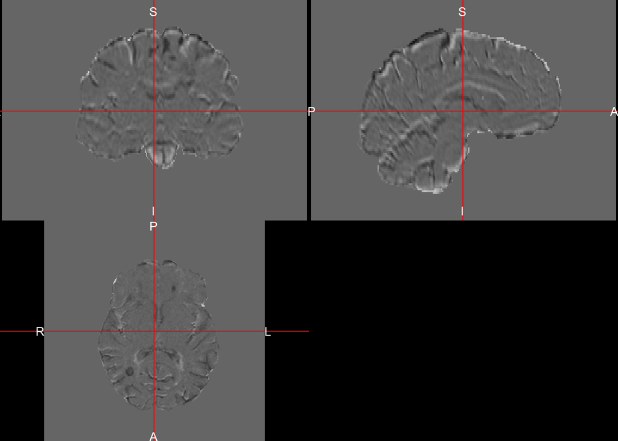

```r
outfiles = gsub("[.]nii", "_N4_reg.nii", files)
f_outfiles = outfiles[c("f_t1", "f_t2", "f_pd", "f_flair")]
f_outfiles = gsub("[.]nii", "_tobase.nii", f_outfiles)
b_outfiles = outfiles[c("base_t1", "base_t2", "base_pd", "base_flair")]
df = data.frame(type = c("t1", "t2", "pd", "flair"), stringsAsFactors = FALSE)
df$base = b_outfiles[paste0("base_", df$type)]
df$f = f_outfiles[paste0("f_", df$type)]
rownames(df) = df$type
df$type = NULL
brainmask = readNIfTI(file.path(homedir, "Brain_Mask.nii.gz"),
                      reorient=FALSE)
itype = "t2"
base = readNIfTI(df[itype, "base"], reorient = FALSE)
base = zscore_img(base, mask = brainmask, margin = NULL)
f = readNIfTI(df[itype, "f"], reorient = FALSE)
f = zscore_img(f, mask = brainmask, margin = NULL)
ddf = data.frame(base = c(base), fup = c(f))
ddf = ddf[ brainmask %in% 1, ]
samp = ddf[ sample(nrow(ddf), size=1e5), ]
d = niftiarr(base, base - f)
d = mask_img(d, mask = brainmask)
ortho2(d)
```

## Other useful functions from fslr

- `window_img` - set min and max values of image (good for plotting)
- `drop_img_dim` - drop dimension if is dimension is 1, especially if you have the error `Error: all dim elements > dim[1] must be 1 dim/pixdim mismatch`
- `mask_img` - mask image with an array/nifti object
- `robust_window` - quantile the image then use `window_img` (take out large values)
- `fslhd` and `fslval` can get information from an image without having to read it in
- `checkimg` - checks if an image is character, writes `nifti` to tempfile, returns character
- `check_nifti` - checks if an image is `nifti`, reads filename, returns `nifti`

## Overview

1. `oro.nifti` - reading/writing nifti objects
2. `ANTsR`
   - bias field corrrection
   - registration: linear, non-linear (symmetric)
3. `fslr`
   - can perform image operations from FSL
   - has helper functions for `nifti` objects
4. extrantsr - helper functions for ANTsR
   - wrapper functions for preprocessing

[output not shown]